# Assignment 2: Keys and Creatures

Introduction to Programming (CSSE7030)  
**Due: 24 October 2025, 15:00 GMT+10**

Published

October 15, 2025

## Introduction

Keys and Creatures is a dungeon crawling puzzle game tasking the player with collecting keys which open doors that can be used to escape. The player must beware however, as they are not alone! Roaming each dungeon are mysterious creatures whose only goal is to eat the player. In this assignment you will be implementing this text-based game, following the Model-View-Controller design paradigm.

## Getting Started

Download `a2.zip` from Blackboard. This archive contains the necessary files to start your assignment. Once extracted, the `a2.zip` archive will provide the following files:

- `a2.py`: *This is the only file where you write your code* and is the *only* `.py` file you will submit. *Do not* make changes to any other files.
- `support.py`: *Do not modify or submit this file*, it contains pre-defined constants to use in your assignment. In addition to these, you are encouraged to create your own constants in `a2.py` where possible.
- `display.py`: *Do not modify or submit this file*, it contains view classes to display your assignment in a visually appealing manner.
- `gameplay/`: This folder contains a number of example outputs generated by playing the game using a fully-functional completed solution to this assignment. The purpose of the files in this folder is to help you understand how the game works, and how output should be formatted.
- `levels/` This folder contains a small collection of files used to initialize games of *Keys and Creatures*. In addition to these, you are encouraged to create your own files to help test your implementation where possible.

If you also wish to download this task sheet you must first click `View Fullscreen` at the top of the page. This will open the task sheet in a new browser tab. On this tab, use `Ctrl-P` to print the page, and select `Save to PDF` as the output location. The print button on Blackboard only captures the first two or so pages of this sheet (a limitation of Blackboard beyond our control).

**Caution**

The task sheet may be modified throughout the course of the assignment as issues are identified. These updates will appear online, but will **not** be reflected in a previously downloaded copy. Please regularly check the changelog **online** to ensure you are working with the most up to date version of the task sheet.

## Gameplay

This section provides a high-level overview of gameplay, and is intended to provide you with an idea of the behaviour of a fully completed assignment. Where interactions are not explicitly mentioned in this section, please see the Implementation section.

**Important**

Do not simply implement the behaviour described here using your own structure; you *must* implement the individual functions, classes, and methods described in the Implementation section. Inputs and outputs must match *exactly* what is expected. Refer to the Implementation section, the given examples, and the provided Gradescope tests for clarification on required prompts and outputs.

The game revolves around a rectangular *dungeon* that is constructed out of uniformly sized *tiles*. Each tile represents a *position* on the board. The dungeon also contains a number of *entities*, namely the player and a set of *creatures*. Entities occupy positions on the board, with each position containing at most one entity.

Tiles can either be *blocking* or not blocking, with blocking tiles not allowing any entity to occupy that position. Certain tiles contain *items* that are picked up and *consumed* by an entity if it moves onto that tile. Each item can only be consumed once. When an item is consumed by an entity, that entity is enhanced it up in some way. *Keys* are special items that can only be consumed by the player. When the player consumes all keys, any *door* within the dungeon *opens*.

Entities each possess a *speed*, and *magic* value. An entity’s speed denotes how many positions they will move in a single turn. An entity’s magic denotes how well it can defend itself from attacks. The player additionally possess a *health* value, and dies when this value drops to 0.

Gameplay is conducted in turns. Each turn, the player may take an action. This action can be to move positions, or to wait in place. Players can move either left, right, up, or down. After the player has moved, each enemy then selects either left, right, up, or down, and moves in the chosen direction. When an entity moves, it moves in a straight line in the chosen direction, moving a number of positions equal to its speed. Moves are conducted one position at a time, and if at any point during a move the entity would move onto a position containing either a blocking tile or another entity, the move ends prematurely. Items are only consumed if an entity finishes a move on the corresponding tile, not if they moved through it.

When a creature ends a move directly adjacent to the player, it attacks them. Diagonal tiles are not considered adjacent. When a creature attacks a player with equal or less magic, the player loses one health. But, if a creature attacks a player with greater magic, the player expends one magic to teleport that creature far away, immediately removing it from the game instead.

The game ends when one of the following occurs:

- The player wins, when after all entities have made a move for the turn, the player is alive, and located on an open door.
- The player loses, when after all entities have made a move for the turn, the player is not alive.

After starting a game of *Keys and Creatures*, the initial game state is printed to the screen, the player is welcomed using `WELCOME_MSG` from `support.py`, and the following game loop then occurs:

1. The player is repeatedly prompted to enter a command using `COMMAND_PROMPT` from `support.py` until they enter a valid command. Valid commands are given in Table 1.
2. Action is taken as per the command entered by the player. The action that should occur is described in Table 1.
3. One by one, each creature selects a direction, and then moves in the selected direction. Details for how directions are selected will be described as relevant in the implementation section.
4. The display is updated by printing the current game state to the screen.
5. If the game is not over, gameplay returns to step 1. Otherwise gameplay advances to step 6.
6. Either `WIN_MSG` or `LOSS_MSG` from `support.py` is printed to the screen informing the player that they won or lost the game as appropriate.
7. The program terminates gracefully.

Table 1: Valid commands and the actions that should be taken. Commands are case insensitive. If the command entered by the user does not exactly match one of the commands in this table (up to case), then no action should be taken `INVALID_COMMAND_MSG` from `support.py` should be printed to the screen, and gameplay should return immediately to step 1.

[output not shown]

## Implementaion

**Important**

You are **not** permitted to add any additional import statements to `a2.py`. Doing so will result in a deduction of up to 100% of your mark. You must not modify or remove the import statements already provided to you in `a2.py`. Removing or modifying these existing import statements may result in your code not functioning, and may result in a deduction of up to 100% of your mark.

### Required Classes and Methods

This section outlines the classes and methods you are **required** to implement in `a2.py`. Your program must operate *exactly* as specified. In particular, your program’s output must match *exactly* with the expected output. Your program will be marked automatically so minor differences in output (such as whitespace or casing) *will* cause tests to fail resulting in *zero marks* for that test.

You will be following the Apple Model-View-Controller design pattern when implementing this assignment. You have been provided the view component, and are required to implement a number of classes in order to complete the Model and Controller components.

The class diagram in Figure 1 provides an overview of all of the classes you must implement in your assignment, and the basic relationships between them. The details of these classes and their methods are described in depth later in this section. Within Figure 1:

- Orange classes are those provided to you in the supporting files.
- Green classes are abstract classes (superclasses). However, you are not required to enforce the abstract nature of the green classes in their implementation. The purpose of this distinction is to indicate to you that you should only ever instantiate the blue classes in your program (though you should instantiate the green classes to test them before beginning work on their subclasses).
- Blue classes are concrete classes (subclasses).
- Solid arrows indicate inheritance (i.e. the “is-a” relationship).
- Dotted arrows indicate composition (i.e. the “has-a” relationship). An arrow marked with 1-1 denotes that each instance of the class at the base of the arrow contains exactly one instance of the class at the head of the arrow. An arrow marked with 1-N denotes that each instance of the class at the base of the arrow may contain many instances of the class at the head of the arrow.

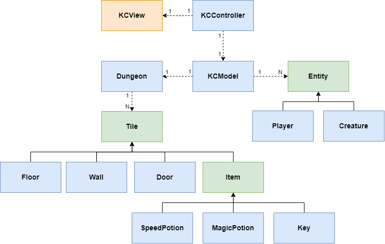

Figure 1: Basic UML diagram for the classes in assignment 2.

**Note**

You are awarded marks for the number of tests passed by your classes when they are tested *independently* of one another. Thus an incomplete assignment with *some* working classes may well be awarded more marks than a complete assignment with faulty classes.

Each class is accompanied with some examples for usage to help you *start* your own testing. You should also test your methods with other values to ensure they operate according to the descriptions.

### Model

The following are the classes and methods you are required to implement as part of the model. You should develop the classes in the order in which they are described in this section and test each one (including on Gradescope) before moving on to the next class. Functionality marks are awarded for each class (and each method) that work correctly. You will likely do very poorly if you submit an attempt at every class, where no classes work according to the description. Some classes require significantly more time to implement than others. The marks allocated to each class are not necessarily an indication of their difficulty or the time required to complete them. You are allowed (and encouraged) to write additional helper methods for any class to help break up long methods, but these helper methods MUST be private (i.e. they must be named with a leading underscore).

**Note**

In the following tasks, you will encounter the `Position` type. This is simply an alias for `tuple[int, int]` used for readability, and is defined in `support.py`

#### Task 1 `Tile()`

`Tile` is an abstract class from which all instantiated types of tile inherit. This class provides default tile behavior, which can be inherited or overridden by specific types of tile. All tiles are represented by a single character identifier, and can either be blocking, or not blocking.

Abstract tiles are not blocking, and are represented by the symbol `T`.

`Tile` must implement the following methods:

- `__init__(self)`  
  Instantiate a new tile.
- `__str__(self) -> str`  
  Returns the identifier that represents this tile.
- `__repr__(self) -> str`  
  Returns a string which could be copied and pasted into a REPL to construct a new instance identical to self.
- `is_blocking(self) -> bool`  
  Returns if this tile is blocking or not.

Example:

```python
>>> tile = Tile()
>>> tile
```

```
Tile()
```

```python
>>> str(tile)
```

```
'T'
```

```python
>>> tile.is_blocking()
```

```
False
```

#### Task 2 `Floor(Tile)`

`Floor` is a non-blocking tile representing walkable ground. Floor tiles are represented by a single space ().

Example:

```python
>>> tile = Floor()
>>> tile
```

```
Floor()
```

```python
>>> str(tile)
```

```
' '
```

```python
>>> tile.is_blocking()
```

```
False
```

#### Task 3 `Wall(Tile)`

`Wall` is a blocking tile representing impassable dungeon walls. Wall tiles are represented by the symbol `W`.

Example:

```python
>>> tile = Wall()
>>> tile
```

```
Wall()
```

```python
>>> str(tile)
```

```
'W'
```

```python
>>> tile.is_blocking()
```

```
True
```

#### Task 4 `Door(Tile)`

`Door` is a tile that represents a goal for the player. Door tiles can either be open or closed. Door tiles are blocking when closed, and not blocking when open. Closed door tiles are represented by the symbol `D`, and open door tiles are represented by the symbol symbol `O`.

To support this extended functionality, The `__init__` method of `Door` takes in an additional argument. In addition to the `Tile` methods that must be supported, `Door` must implement the following methods:

- `__init__(self, is_open: bool)`  
  Initialise a new `Door` instance, which is open if `is_open` is `True`, and closed otherwise.
- `is_open(self) -> bool`  
  Return if this door is currently open or not.
- `set_open(self, is_open: bool)`  
  Set this door to be open if `is_open` is `True`, and set this door to be closed otherwise.

Example:

```python
>>> tile = Door(False)
>>> tile
```

```
Door(False)
```

```python
>>> str(tile)
```

```
'D'
```

```python
>>> tile.is_blocking()
```

```
True
```

```python
>>> tile.is_open()
```

```
False
```

```python
>>> tile.set_open(True)
>>> tile
```

```
Door(True)
```

```python
>>> str(tile)
```

```
'O'
```

```python
>>> tile.is_blocking()
```

```
False
```

```python
>>> tile.is_open()
```

```
True
```

#### Task 5 `Entity()`

`Entity` is an abstract class from which all instantiated types of entity inherit. This class provides default entity behavior, which can be inherited or overridden by specific types of entities. Each entity occupies a position, and has a speed and magic value. Positions are represented as (row, column) integer tuples, where `(0, 0)` denotes the top-left corner of the dungeon. Like tiles, each entity is represented by a single character identifier. Base entities are represented by the character `E`.

`Entity` must implement the following methods:

- `__init__(self, pos: Position, speed: int, magic: int)`  
  Instantiate a new entity at the given position, with the specified speed and magic.
- `__repr__(self) -> str`  
  Returns a string which could be copied and pasted into a REPL to construct a new instance identical to self.
- `__str__(self) -> str`  
  Returns this entities identifier, row, column, speed, and magic; comma separated.
- `get_id(self) -> str`  
  Returns the single character that represents this entity.
- `get_position(self) -> Position`  
  Returns this entity’s position.
- `set_position(self, new_pos: Position)`  
  Sets this entity’s position to the specified value.
- `get_speed(self) -> int`  
  Returns this entity’s speed.
- `set_speed(self, new_speed: int)`  
  Sets this entity’s speed to the specified value.
- `get_magic(self) -> int`  
  Returns this entity’s magic.
- `set_magic(self, new_magic: int)`  
  Sets this entity’s magic to the specified value.

Example:

```python
>>> entity = Entity((0,0), 1, 1)
>>> entity
```

```
Entity((0, 0), 1, 1)
```

```python
>>> str(entity)
```

```
'E,0,0,1,1'
```

```python
>>> entity.get_id()
```

```
'E'
```

```python
>>> entity.get_position()
```

```
(0, 0)
```

```python
>>> entity.get_speed()
```

```
1
```

```python
>>> entity.get_magic()
```

```
1
```

```python
>>> entity.set_position((3,1))
>>> entity
```

```
Entity((3, 1), 1, 1)
```

```python
>>> entity.set_speed(42)
>>> entity
```

```
Entity((3, 1), 42, 1)
```

```python
>>> entity.set_magic(9001)
>>> entity
```

```
Entity((3, 1), 42, 9001)
```

```python
>>> str(entity)
```

```
'E,3,1,42,9001'
```

#### Task 6 `Player(Entity)`

A `Player` is an entity controlled by the player, and can be attacked by creatures. In addition to the regular entity values, `Player` entities additionally track a health value, and are alive only when this value is greater than 0. Players can also determine the locations from which they could be attacked. Player entities are identified by the symbol `P`.

To support this extended functionality, The `__init__` method of `Player` takes in an additional argument. In addition to the `Entity` methods that must be supported, `Player` must implement the following methods:

- `__init__(self, pos: Position, speed: int, magic: int, health: int)`  
  Instantiate a new player at the given position, with the specified speed, magic, and health.
- `__str__(self) -> str`  
  Returns this player’s identifier, row, column, speed, magic, and health; comma separated.
- `get_health(self) -> int`  
  Returns this player’s current health level.
- `set_health(self, new_health: int)`  
  Sets this player’s health to the specified value.
- `is_alive(self) -> bool`  
  Returns `True` if this player is alive, and `False` otherwise.
- `adjacent_positions(self) -> tuple[Position]`  
  Returns a tuple containing the positions directly adjacent to this player. Diagonal positions are not considered adjacent. Positions should be returned in the following order: Above, to the left, to the right, below.

Example:

```python
>>> player = Player((0,0), 1, 1, 5)
>>> player
```

```
Player((0, 0), 1, 1, 5)
```

```python
>>> str(player)
```

```
'P,0,0,1,1,5'
```

```python
>>> player.get_id()
```

```
'P'
```

```python
>>> player.get_position()
```

```
(0, 0)
```

```python
>>> player.get_speed()
```

```
1
```

```python
>>> player.get_magic()
```

```
1
```

```python
>>> player.get_health()
```

```
5
```

```python
>>> player.is_alive()
```

```
True
```

```python
>>> player.adjacent_positions()
```

```
((-1, 0), (0, -1), (0, 1), (1, 0))
```

```python
>>> player.set_position((3,-1))
>>> player
```

```
Player((3, -1), 1, 1, 5)
```

```python
>>> player.adjacent_positions()
```

```
((2, -1), (3, -2), (3, 0), (4, -1))
```

```python
>>> player.set_health(0)
>>> player
```

```
Player((3, -1), 1, 1, 0)
```

```python
>>> player.is_alive()
```

```
False
```

```python
>>> player.set_health(-4)
>>> player
```

```
Player((3, -1), 1, 1, -4)
```

```python
>>> player.is_alive()
```

```
False
```

#### Task 7 `Creature(Entity)`

A `Creature` is an entity with some level of autonomy. They can select movement directions to bring them closer to their intended target. Unlike Azin and the tutor team, creatures are not very intelligent; creatures cannot use magic, and ignore their current speed when deciding what direction to move! Creature entities are identified by the symbol `C`.

In addition to the `Entity` methods that must be supported, `Creature` must implement the following methods:

- `choose_move(self, target: Entity) -> str`  
  Return the movement direction that would result in the smallest euclidean distance to the given target. Movement can either be upwards, to the left, to the right, or downwards. Distance should be measured using the `euclidean_distance` function provided in `support.py`. Creatures ignore obstacles and the effect of speed when determining distance, that is they assume they will move exactly one position in any direction. In the event of a tie, direction preference, in order from highest to lowest, should be upwards, to the left, to the right, and finally downwards. Movements should be returned as the string the user would enter to move in that direction.

Example:

```python
>>> la_creatura = Creature((1,1), 4, 9)
>>> la_creatura
```

```
Creature((1, 1), 4, 9)
```

```python
>>> str(la_creatura)
```

```
'C,1,1,4,9'
```

```python
>>> la_creatura.get_id()
```

```
'C'
```

```python
>>> target = Entity((0,0), 1, 1)
la_creatura.choose_move(target)
```

```
'up'
```

```python
>>> target.set_position((1,0))
la_creatura.choose_move(target)
```

```
'left'
```

```python
>>> target.set_position((6,2))
la_creatura.choose_move(target)
```

```
'down'
```

```python
>>> target.set_position((2,6))
la_creatura.choose_move(target)
```

```
'right'
```

```python
>>> target.set_position((1,1))
la_creatura.choose_move(target)
```

```
'up'
```

#### Task 8 `Item(Tile)`

`Item` is an abstract class from which all instantiated types of item inherit. This class provides default item behavior, which can be inherited or overridden by specific types of item. Items are a special type of non-blocking tile, containing some object that an entity can pick up and consume. Items can only be consumed once per game. When an item is consumed by an entity, it may affect that entity in some manner. Generic items have no such effect.

Items are represented by a single character like normal tiles, but once an item has been consumed, the symbol representing that particular item is replaced with the character `U`. Generic items are represented by the character `I`.

To support this extended functionality, The `__init__` method of `Item` takes in an additional argument. In addition to the `Tile` methods that must be supported, `Item` must implement the following methods:

- `__init__(self, consumed: bool)`  
  Instantiate a new `Item` that is already consumed if `consumed` is `True`, and not otherwise.
- `is_consumed(self) -> bool`  
  Returns `True` if this item is consumed, and `False` otherwise.
- `pick_up(self, entity: Entity)`  
  Attempts to have the given entity pick up and consume this item, applying any relevant effects. Does nothing if the item has already been consumed.

Example:

```python
>>> item = Item(False)
>>> item
```

```
Item(False)
```

```python
>>> str(item)
```

```
'I'
```

```python
>>> item.is_blocking()
```

```
False
```

```python
>>> item.is_consumed()
```

```
False
```

```python
>>> entity = Entity((0,0), 1, 1)
>>> entity
```

```
Entity((0, 0), 1, 1)
```

```python
>>> item.pick_up(entity)
>>> item
```

```
Item(True)
```

```python
>>> str(item)
```

```
'U'
```

```python
>>> item.is_consumed()
```

```
True
```

#### Task 9 `SpeedPotion(Item)`

A `SpeedPotion` is an item that increases the speed of the entity that picked it up by 1. Speed potions are represented using the symbol `S`.

Example:

```python
>>> item = SpeedPotion(False)
>>> item
```

```
SpeedPotion(False)
```

```python
>>> str(item)
```

```
'S'
```

```python
>>> item.is_blocking()
```

```
False
```

```python
>>> entity = Entity((0,0), 1, 1)
>>> entity.get_speed()
```

```
1
```

```python
>>> item.pick_up(entity)
>>> entity.get_speed()
```

```
2
```

```python
>>> str(item)
```

```
'U'
```

```python
>>> item.pick_up(entity)
>>> entity.get_speed()
```

```
2
```

```python
>>> str(item)
```

```
'U'
```

#### Task 10 `MagicPotion(Item)`

A `MagicPotion` is an item that increases the magic of the entity that picked it up by 1. Magic potions are represented using the symbol `M`.

Example:

```python
>>> item = MagicPotion(False)
>>> item
```

```
MagicPotion(False)
```

```python
>>> str(item)
```

```
'M'
```

```python
>>> item.is_blocking()
```

```
False
```

```python
>>> entity = Entity((0,0), 1, 1)
>>> entity.get_magic()
```

```
1
```

```python
>>> item.pick_up(entity)
>>> entity.get_magic()
```

```
2
```

```python
>>> str(item)
```

```
'U'
```

```python
>>> item.pick_up(entity)
>>> entity.get_magic()
```

```
2
```

```python
>>> str(item)
```

```
'U'
```

#### Task 11 `Key(Item)`

A `Key` is a special item that can only be picked up by player entities. They have no direct effect when picked up. Keys are represented using the symbol `K`.

Example:

```python
>>> key = Key(False)
>>> key
```

```
Key(False)
```

```python
>>> str(key)
```

```
'K'
```

```python
>>> key.is_blocking()
```

```
False
```

```python
>>> entity = Entity((0,0), 1, 1)
>>> entity
```

```
Entity((0, 0), 1, 1)
```

```python
>>> key.pick_up(entity)
>>> key.is_consumed()
```

```
False
```

```python
>>> entity = Creature((0,0), 1, 1)
>>> entity
```

```
Creature((0, 0), 1, 1)
```

```python
>>> key.pick_up(entity)
>>> key.is_consumed()
```

```
False
```

```python
>>> entity = Player((0,0), 1, 1, 1)
>>> entity
```

```
Player((0, 0), 1, 1, 1)
```

```python
>>> key.pick_up(entity)
>>> key.is_consumed()
```

```
True
```

#### Task 12 `Dungeon()`

`Dungeon` represents a level of *Keys and Creatures*. A dungeon is structured as a rectangular set of tiles. The set of tiles will not change after a `Dungeon` object is created.

`Dungeon` must implement the following methods:

- `__init__(self, tiles: list[list[Tile]])`  
  Instantiate a dungeon from the provided tile structure. Tiles should be provided as an ordered list of rows, with the first list in the structure representing the topmost row, and the last list in the structure representing the bottommost row. Each row should be ordered with the first tile representing the leftmost, and the last tile representing the rightmost. Preconditions to this method are that `tiles` will contain at least one row, and that each row of `tiles` contains the same number of columns.
- `__repr__(self) -> str`  
  Returns a string which could be copied and pasted into a REPL to construct a new instance identical to self.
- `__str__(self) -> str`  
  Returns the string representation of each tile in the dungeon, ordered from left to right, grouped into rows from top to bottom separated by new lines.
- `get_tiles(self) -> list[list[Tile]]`  
  Returns the structured set of tiles representing this dungeon, structured as an ordered list of rows, with the first list in the structure representing the topmost row, and the last list in the structure representing the bottommost row. Each row should be ordered with the first tile representing the leftmost, and the last tile representing the rightmost.
- `get_doors(self) -> dict[Position, Door]`  
  Returns a dictionary containing all doors within the dungeon. The keys of the dictionary should be the positions of each door, and the value associated with each key should be the door tile corresponding to that position.
- `get_items(self) -> dict[Position, Item]`  
  Returns a dictionary containing all items within the dungeon. The keys of the dictionary should be the positions of each item, and the value associated with each key should be the item tile corresponding to that position.
- `keys_remaining(self) -> int`  
  Returns the number of keys that have not yet been picked up within this dungeon.
- `open_doors(self)`  
  Open all doors within this dungeon.

Example:

```python
>>> tiles = [[Wall(), Tile(), Door(False)], [Floor(), Key(False), Key(True)], [Floor(), Floor(), Door(False)], [Item(False), SpeedPotion(False), MagicPotion(False)]]
>>> dungeon = Dungeon(tiles)
>>> dungeon
```

```
Dungeon([[Wall(), Tile(), Door(False)], [Floor(), Key(False), Key(True)], [Floor(), Floor(), Door(False)], [Item(False), SpeedPotion(False), MagicPotion(False)]])
```

```python
>>> str(dungeon)
```

```
'WTD\n KU\n  D\nISM'
```

```python
>>> dungeon.get_tiles()
```

```
[[Wall(), Tile(), Door(False)],
 [Floor(), Key(False), Key(True)],
 [Floor(), Floor(), Door(False)],
 [Item(False), SpeedPotion(False), MagicPotion(False)]]
```

```python
>>> dungeon.get_doors()
```

```
{(0, 2): Door(False), (2, 2): Door(False)}
```

```python
>>> dungeon.get_items()
```

```
{(1, 1): Key(False),
 (1, 2): Key(True),
 (3, 0): Item(False),
 (3, 1): SpeedPotion(False),
 (3, 2): MagicPotion(False)}
```

```python
>>> dungeon.keys_remaining()
```

```
1
```

```python
>>> dungeon.open_doors()
>>> dungeon.get_doors()
```

```
{(0, 2): Door(True), (2, 2): Door(True)}
```

```python
>>> str(dungeon)
```

```
'WTO\n KU\n  O\nISM'
```

#### Task 13 `KCModel()`

`KCModel` models the logical state of a game of Keys and Creatures.

Here, each creature is associated with a fixed priority to determine the order in which they move after the player has taken an action. This is important as creatures may move into the path of one another and block movement.

`KCModel` must implement the following methods:

- `__init__(self, dungeon: Dungeon, player: Player, creatures: list[Creature])`  
  Instantiates a new `KCModel` using the given dungeon, player, and creatures. The list of creatures is given in priority order, with the first creature in the list having highest priority, and the last creature in the list having lowest priority.
- `__repr__(self) -> str`  
  Returns a string which could be copied and pasted into a REPL to construct a new instance identical to self.
- `__str__(self) -> str`  
  Returns the string representation of the dungeon, but with the tiles at locations occupied by entities replaced with the identifier of the corresponding entity. You may assume there is no more than one entity at each location, and that each entity exists at a valid position within the dungeon.
- `get_dungeon(self) -> Dungeon`  
  Return this model’s dungeon instance.
- `get_player(self) -> Player`  
  Return this model’s player instance.
- `get_creatures(self) -> list[Creature]`  
  Return this model’s creatures, in decreasing order of priority.
- `has_won(self) -> bool`  
  Return `True` if the player has won the game per the Gameplay section, and `False` otherwise.
- `has_lost(self) -> bool`  
  Return `True` if the player has lost the game per the Gameplay section, and `False` otherwise.
- `move_entity(self, entity: Entity, move: str)`  
  Moves the given entity in the direction specified by move. This movement should be repeated a (total) number of times equal to the entity’s speed. If a movement would place the entity at a position with either a blocking tile or another entity, then it (and all future repetitions of the movement) should be aborted. The entity should attempt to pick up any item at its final location. A precondition to this function is that `move` will be `up`, `down`, `left`, `right`, or `wait`.
- `make_move(self, move: str)`  
  Performs the player’s desired action. After this action, each creature, in order from highest priority to lowest, will then pick a direction and perform a move in that chosen direction. Items should be picked up and attacks should be performed after each entity moves in accordance with the gameplay rules. A precondition to this function is that `move` will be `up`, `down`, `left`, `right`, or `wait`.

Example:

```python
>>> tiles = [[Wall(),Wall(),Wall(),Wall(),Wall()],[Wall(),Floor(),Door(False),Wall(),Wall()],[Wall(),Key(False),Key(False),Door(False),Wall()],[Wall(),Floor(),SpeedPotion(False),Floor(),Wall()],[Wall(),Wall(),Wall(),Wall(),Wall()]]
>>> dungeon = Dungeon(tiles)
>>> player = Player((1,1), 1, 1, 3)
>>> creatures = [Creature((3,3), 2, 0), Creature((3,1), 1, 0)]
>>> model = KCModel(dungeon, player, creatures)
>>> model
```

[output not shown]

```python
>>> str(model)
```

```
'WWWWW\nWPDWW\nWKKDW\nWCSCW\nWWWWW'
```

```python
>>> model.get_dungeon()
```

```
Dungeon([[Wall(), Wall(), Wall(), Wall(), Wall()], [Wall(), Floor(), Door(False), Wall(), Wall()], [Wall(), Key(False), Key(False), Door(False), Wall()], [Wall(), Floor(), SpeedPotion(False), Floor(), Wall()], [Wall(), Wall(), Wall(), Wall(), Wall()]])
```

```python
>>> model.get_player()
```

```
Player((1, 1), 1, 1, 3)
```

```python
>>> model.get_creatures()
```

```
[Creature((3, 3), 2, 0), Creature((3, 1), 1, 0)]
```

```python
>>> model.has_won()
```

```
False
```

```python
>>> model.has_lost()
```

```
False
```

```python
>>> c1 = creatures[0]
>>> c1
```

```
Creature((3, 3), 2, 0)
```

```python
>>> print(model)
```

```
WWWWW
WPDWW
WKKDW
WCSCW
WWWWW
```

```python
>>> model.move_entity(c1, "left")
```

```python
>>> print(model)
```

```
WWWWW
WPDWW
WKKDW
WCC W
WWWWW
```

```python
>>> model.move_entity(c1, "up")
```

```python
>>> print(model)
```

```
WWWWW
WPDWW
WKCDW
WCU W
WWWWW
```

```python
>>> model.move_entity(c1, "down")
```

```python
>>> print(model)
```

```
WWWWW
WPDWW
WKKDW
WCC W
WWWWW
```

```python
>>> model.make_move("down")
```

```python
>>> print(model)
```

```
WWWWW
W DWW
WPKDW
WCU W
WWWWW
```

```python
>>> model.make_move("wait")
```

```python
>>> print(model)
```

```
WWWWW
W DWW
WPKDW
WCU W
WWWWW
```

```python
>>> model.make_move("right")
```

```python
>>> print(model)
```

```
WWWWW
W OWW
WCPOW
W U W
WWWWW
```

```python
>>> model.has_lost()
```

```
True
```

```python
>>> player.set_position((1,2))
>>> print(model)
```

```
WWWWW
W PWW
WCUOW
W U W
WWWWW
```

```python
>>> model.has_won()
```

```
False
```

```python
>>> model.has_lost()
```

```
True
```

```python
>>> player.set_health(1)
>>> model.has_won()
```

```
True
```

```python
>>> model.has_lost()
```

```
False
```

```python
>>> model.get_dungeon().get_doors()[(1,2)].set_open(False)
>>> model.has_won()
```

```
False
```

### Controller

The controller is a single class, `KCController()`, which you must implement according to this section. You will also implement the `play_game` function to construct the controller, and the `load_model` function to assist with constructing game states as required. Unlike with the model, there is no recommended task completion order in this section. It will likely be helpful to work on certain tasks in parallel to implement features. Please refer to the `gameplay/` folder provided with this assignment for examples of intended controller behavior. Note that for all such examples, the file initially loaded is `levels/level1.txt`.

#### Task 14 `load_model(file: str) -> KCModel`

`load_model` is a *function* that attempts to load a KCModel from the file located at the path specified by `file`, assuming that it contains *exactly*: The string representation of the dungeon, followed by two newline characters; followed by the string representation of the player; followed by another newline character; followed finally by the string representation of each creature in decreasing priority order, separated by newline characters. As there is no way to distinguish between items that have been picked up, such cases should be loaded as a generic `Item`.

You may assume that the structure of the file is valid (That is, follows the structure above, with a rectangular dungeon representation). But, you **cannot** assume that the values within `file` are valid. This function should raise a `ValueError` if you encounter any of the errors specified in Table 2 (excluding the first row). If a `ValueError` is raised, its message should be that presented in the corresponding row of Table 2.

You should *not* handle the case where `file` does not exist in this function.

#### Task 15 `KCController()`

`KCController()` is the controller class for the overall game. The controller is responsible for maintaining instances of the model and view classes, handling player input, and facilitating communication between the model and view classes.

**Note**

One of the most important skills in programming is the ability to understand and use someone elses code. You will be expected to understand and correctly use the `KCView` class provided in `display.py`.

`KCController()` should implement the following methods:

- `__init__(self, initial_state: KCModel)`  
  Instantiates the controller using the given state. Creates a view class instance. You should make use of the provided `KCView` class in `display.py`.
- `__repr__(self) -> str`  
  Returns a string which could be copied and pasted into a REPL to construct a new instance identical to self.
- `__str__(self) -> str`  
  Returns the string representation of the model instance.
- `print_game(self)`  
  Update the display by printing out the current game state. The display should contain (from top to bottom): A banner containing the game name; A depiction of the current dungeon, with entities depicted at their current positions, and a depiction of the player with (from left to right), their current health, speed, and magic. See Figure 2 for an example of what this should look like. You will need to call the `draw_game` method of the controller’s `KCView` instance, providing the required parameters.
- `load_game(self, file: str)`  
  Replace the current game state with the state contained in `file`. You may assume that the structure of the file is valid. But, you **cannot** assume that the values within `file` are valid. This function should raise a `ValueError` if you encounter any of the errors specified in Table 2 (excluding the first row). If a `ValueError` is raised, its message should be that presented in the corresponding row of Table 2. You should *not* handle the case where `file` does not exist in this function.
- `get_command(self) -> str`  
  Repeatedly prompts the user until they enter a valid command. Returns the first valid command entered by the user. The possible valid commands are given in Table 1. Whenever the user enters an invalid command, `INVALID_COMMAND_MSG` from `support.py` should be printed to the screen before the player is re-prompted. The message used to prompt the player to enter a command should be `COMMAND_PROMPT` from `support.py`. Commands are case insensitive, but should be returned in lower case.
- `play(self)`  
  Conducts a game of Keys and Creatures from start to finish, following the Gameplay section

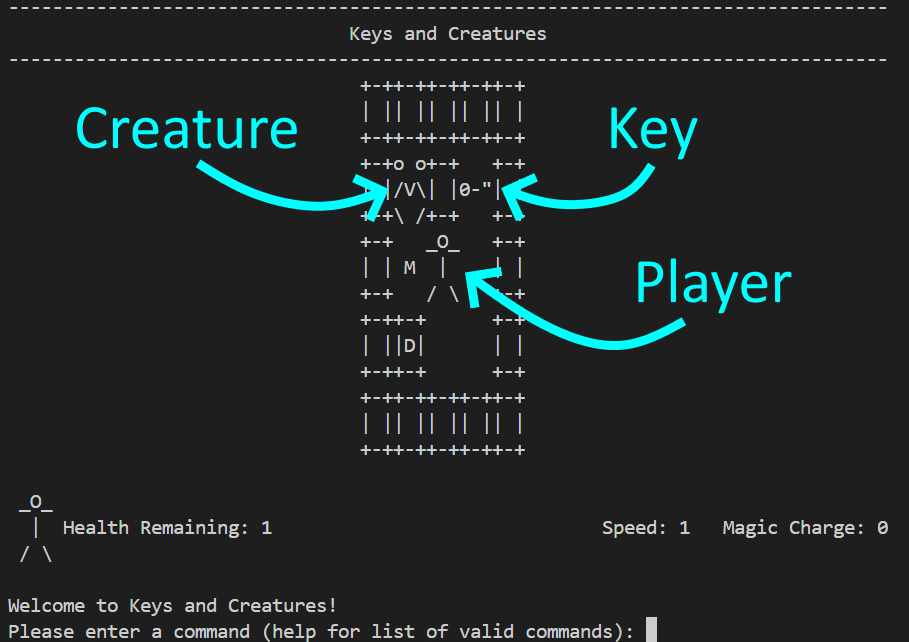

Figure 2: Example of game display using the initial state of `levels/level1.txt`. Key, Creature and Player instances are annotated. Other items and doors are denoted using their symbol.

Table 2: Messages that should be printed given problems with loaded file. Messages are given in order of precedence. That is to say: if multiple errors occur simultaneously, the topmost error in this table should be displayed.

| Error | Message from `support.py` to be printed |
| --- | --- |
| File does not exist | `FILE_NOT_FOUND_MSG` |
| Tiles contain a character that is not a valid `Tile` ID | `INVALID_TILE_MSG` |
| ID of player entity is not `PLAYER_ID`, or player values contain a non-integer | `INVALID_PLAYER_MESSAGE` |
| ID of creature entity is not `CREATURE_ID`, or creature values contain a non-integer | `INVALID_CREATURE_MESSAGE` |

#### Task 16 `play_game(file: str)`

The play game function should be fairly short and do *exactly* three things:

1. Load a `KCModel` instance from the game state located in `file` using the `load_model` function. You may assume that no errors will be raised when loading the `KCModel`.
2. Construct a controller instance with the loaded game state.
3. Play a single game of Keys and Creatures from beginning to end (using `.play()`)

#### Task 17 `main()`

The purpose of the main function is to allow you to test your own code. Like the play game function, the main function should be short (A single line) and do exactly one thing: call `play_game` with a file name of your choice.

## Assessment and Marking Criteria

This assignment assesses following course learning objectives:

1. Apply program constructs such as variables, selection, iteration and sub-routines,
2. Apply basic object-oriented concepts such as classes, instances and methods,
3. Read and analyse code written by others,
4. Analyse a problem and design an algorithmic solution to the problem,
5. Read and analyse a design and be able to translate the design into a working program, and
6. Apply techniques for testing and debugging.

There are a total of 100 marks for this assessment item.

### Functionality

Your program’s functionality will be marked out of a total of 50 marks.

The breakdown of marks for each implementation section is as follows:

- Model: 35 Marks
- Controller: 15 Marks

Your assignment will be put through a series of tests and your functionality mark will be proportional to the number of tests you pass. You will be given a *subset* of the functionality tests before the due date for the assignment.

You may receive partial marks within each section for partially working functions, or for implementing only a few functions.

**Warning**

You need to perform your *own* testing of your program to make sure that it meets **all** specifications given in the assignment. Only relying on the provided tests is likely to result in your program failing in some cases and you losing some functionality marks.

**Note**

Functionality tests are automated, so string outputs need to match *exactly* what is expected.

Your program must run in Gradescope, which uses Python 3.13. Partial solutions will be marked but if there are errors in your code that cause the interpreter to fail to execute your program, you will get zero for functionality marks. If there is a part of your code that causes the interpreter to fail, comment out the code so that the remainder can run. Your program must run using the Python 3.13 interpreter. If it runs in another environment (e.g. Python 3.8 or PyCharm) but not in the Python 3.13 interpreter, you will get zero for the functionality mark. Python versions newer than 3.13 will function correctly provided you do not use language features that are not introduced in the course.

### Code Style

The style of your assignment will be assessed by a tutor. Style will be marked according to the style rubric provided with the assignment. The style mark will be out of 50.

**Note**

Style accounts for half the marks available on this assignment

You are expected to follow the PEP-8 style guidelines discussed in lectures. The key consideration in marking your code style is whether the code is easy to understand. There are several aspects of code style that contribute to how easy it is to understand code. In this assignment, your code style will be assessed against the following criteria:

- Readability
  - Program Structure: Layout of code makes it easy to read and follow its logic. This includes using whitespace to highlight blocks of logic, and ensuring all lines are below 80 characters.
  - Descriptive Identifier Names: Variable, constant, and function names clearly describe what they represent in the program’s logic. Do not use Hungarian Notation for identifiers. In short, this means do not include the identifier’s type in its name, rather make the name meaningful (e.g. employee identifier).
  - Named Constants: Any non-trivial fixed value (literal constant) in the code is represented by a descriptive named constant (identifier).
- Algorithmic Logic
  - Single Instance of Logic: Blocks of code should not be duplicated in your program. Any code that needs to be used multiple times should be implemented as a function.
  - Variable Scope: Variables should be declared locally in the function in which they are needed. Global variables should not be used.
  - Control Structures: Logic is structured simply and clearly through good use of control structures (e.g. loops and conditional statements).
- Object-Oriented Program Structure
  - Classes & Instances: Objects are used as entities to which messages are sent, demonstrating understanding of the differences between classes and instances.
  - Encapsulation: Classes are designed as independent modules with state and behaviour. Methods only directly access the state of the object on which they were invoked. Methods never update the state of another object.
  - Abstraction: Public interfaces of classes are simple and reusable. Enabling modular and reusable components which abstract details.
  - Inheritance & Polymorphism: Subclasses are designed as specialised versions of their superclasses. Subclasses extend the behaviour of their superclass without re-implementing behaviour, or breaking the superclass behaviour or design. Subclasses redefine behaviour of appropriate methods to extend the superclasses’ type. Subclasses do not break their superclass’ interface.
  - Model View Controller: Your program adheres to the Model-View-Controller design pattern. The view and control logic is clearly separated from the model. Model information stored in the controller and passed to the view when required.
- Documentation:
  - Comment Clarity: Comments provide meaningful descriptions of the code. They should not repeat what is already obvious by reading the code (e.g. `# Setting variable to 0`). Comments should not be verbose or excessive, as this can make it difficult to follow the code. Comments must be written in English.
  - Informative Docstrings: Every function should have a docstring that summarises its purpose. This includes describing parameters and return values (including type information) so that others can understand how to use the function correctly.
  - Description of Logic: All significant blocks of code should have a comment (in English) to explain how the logic works. For a small function, this would usually be the docstring. For long or complex functions, there may be different blocks of code in the function. Each of these should have an in-line comment describing the logic.

### Oral Presentation Assessment (**HURDLE**)

**Important**

In **Week 13**, students must attend their enrolled practical session for a brief interview about their assignment code. They will be assessed on the quality of their answers. If a student scores below 50% in the interview, their overall assignment mark will be capped at 50%.

### Assignment Submission

You must submit your assignment electronically via [Gradescope](https://gradescope.com/). You **must** use your UQ email address which is based on your student number (e.g. `s4123456@student.uq.edu.au`) as your Gradescope submission account.

When you login to Gradescope you may be presented with a list of courses. Select `CSSE7030`. You will see a list of assignments. Choose `Assignment 2`. You will be prompted to choose a file to upload. Do *not* select the option to submit using a git repository if it is presented to you. The prompt may say that you can upload any files, including zip files. You **must** submit your assignment as a single Python file called `a2.py` (use this name – all lower case), and *nothing* else. Your submission will be automatically run to determine the functionality mark. If you submit a file with a different name, the tests will **fail** and you will get **zero** for functionality. Do **not** submit *any* sort of archive file (e.g. zip, rar, 7z, etc.).

Upload an initial version of your assignment *at least* one week before the due date. Do this even if it is just the initial code provided with the assignment. If you are unable access Gradescope, make a post on [Edstem](https://edstem.org/au/courses/24510) *immediately*. Excuses, such as you were not able to login or were unable to upload a file will not be accepted as reasons for granting an extension.

When you upload your assignment it will run a **subset** of the functionality autograder tests on your submission. It will show you the results of these tests. It is your responsibility to ensure that your uploaded assignment file runs and that it passes the tests you expect it to pass.

Late submission of the assignment will result in a deduction of 100% of the total possible mark. A one-hour grace period will be applied to the due time, after which time (16:00) your submission will be considered officially late and will receive a mark of 0. Do not wait until the last minute to submit your assignment, as the time to upload it may make it late. **Multiple submissions are allowed and encouraged**, so ensure that you have submitted an almost complete version of the assignment *well* before the submission deadline of 15:00. Your latest submission will be marked. Do not submit after the deadline, as this will result in a late penalty of 100% of the maximum possible mark being applied to your submission.

In the event of exceptional personal or medical circumstances that prevent you from handing in the assignment on time, you may submit a request for an extension. See the course profile for details of how to apply for an extension.

Requests for extensions must be made **before** the submission deadline. The application and supporting documentation (e.g. medical certificate) must be submitted via [myUQ](https://my.uq.edu.au/). You must retain the original documentation for a minimum period of six months to provide as verification, should you be requested to do so.

### Plagiarism and Referencing AI Use

This assignment must be your own individual work. By submitting the assignment, you are claiming it is entirely your own work. You may discuss general ideas about the solution approach with other students. Describing details of how you implement a function or sharing part of your code with another student is considered to be **collusion** and will be counted as plagiarism. You **must not** copy fragments of code that you find on the Internet to use in your assignment.

Artificial Intelligence (AI) and Machine Translation (MT) are emerging tools that may support you in completing this assessment task. You may appropriately use AI and/or MT in completing your assessment tasks. However, you **must clearly reference** any use of AI or MT in each instance. A failure to reference generative AI or MT use may constitute student misconduct under the Student Code of Conduct. Please refer to [AI Guideline](https://learn.uq.edu.au/ultra/courses/_192509_1/outline/edit/document/_11738816_1?courseId=_192509_1&view=content&state=view) that has been provided on the Ultra Blackboard page of the course.

**Important**

You **must** understand all code submitted and submit a **PDF file** alongside with your final code submission. This file must provide detailed information about how the AI tools were used. Please refer to [AI Guideline](https://learn.uq.edu.au/ultra/courses/_192509_1/outline/edit/document/_11738816_1?courseId=_192509_1&view=content&state=view) for guidance on properly documenting interactions with AI.

You are encouraged to complete *both* parts A and B of the [academic integrity modules](https://web.library.uq.edu.au/library-services/it/learnuq-blackboard-help/academic-integrity-modules) *before* starting this assignment. Submitted assignments will be electronically checked for potential cases of plagiarism.